# FIT5215: Deep Learning (2021)

*Chief Examiner:* Prof **Dinh Phung** | dinh.phung@monash.edu  
*Lecturer:* Dr **Peibo Duan** | peibo.duan@monash.edu  
*Tutor:* Mr **Qing Ye** | qing.ye@monash.edu  
Department of Data Science and AI, Faculty of Information Technology, Monash University, Australia

# Deep Neural Networks

### Due: 11:59pm Friday, 30 July 2021 (Friday)

#### Important note: This is an **individual** assignment. It contributes **20%** to you final mark. Read the assignment instruction carefully.

## Instruction

This notebook has been prepared for your to complete Assignment 1. The theme of this assignment is about practical machine learning knowledge and skills in deep neural networks, including feedforward and convolutional neural networks. Some sections have been partially completed to help you get started. **The total marks for this notebook is 100**.

- Before you start, read the entire notebook carefully once to understand what you need to do.
- For each cell marked with **#YOU ARE REQUIRED TO INSERT YOUR CODES IN THIS CELL**, there will be places where you **must** supply your own codes when instructed.

This assignment contains **three** parts:

- Part 1: Questions on theory and knowledge on machine learning and deep learning **[30 points], 30%**
- Part 2: Coding assessment on TensorFlow for Deep Neural Networks (DNN) **[30 points], 30%**
- Part 3: Coding assessment on TensorFlow for Convolution Neural Networks (CNN) **[40 points], 40%**

**Hint**: This assignment was essentially designed based on the lectures and tutorials sessions covered from Week 1 to Week 4. You are strongly recommended to go through these contents thoroughly which might help you to complete this assignment.

## What to submit

This assignment is to be completed individually and submitted to Moodle unit site. **By the due date, you are required to submit one single zip file, named xxx_assignment01_solution.zip where `xxx` is your student ID, to the corresponding Assignment (Dropbox) in Moodle**.

*For example, if your student ID is 12356, then gather all of your assignment solution to folder, create a zip file named 123456_assignment01_solution.zip and submit this file.*

Within this zip folder, you **must** submit the following files:

1. **Assignment01_solution.ipynp**: this is your Python notebook solution source file.
2. **Assingment01_output.html**: this is the output of your Python notebook solution *exported* in html format.
3. Any **extra files or folder** needed to complete your assignment (e.g., images used in your answers).

Since the notebook is quite big to load and work together, one recommended option is to split solution into three parts and work on them seperately. In that case, replace **Assignment01_solution.ipynp** by three notebooks: **Assignment01_Part1_solution.ipynp**, **Assignment01_Part2_solution.ipynp** and **Assignment01_Part3_solution.ipynp**

## Part 1: Theory and Knowledge Questions

[Total marks for this part: 30 points]

The first part of this assignment is for you to demonstrate your knowledge in deep learning that you have acquired from the lectures and tutorials materials. Most of the contents in this assignment are drawn from the tutorials covered from weeks 1 to 4. Going through these materials before attempting this part is highly recommended.

#### **Question 1.1** **Activation function plays an important role in modern Deep NNs. For each of the activation function below, state its output range and find its derivative (show your steps)**

**(a)** Sigmoid: $\sigma(x) = \frac{1}{1+\text{exp}{(-x)}}$

[1.5 points]

**(b)** Tanh: $\sigma(x) = \frac{\exp(x) - \exp{(-x)}}{\exp(x) + \exp{(-x)}}= \frac{1-\exp(-2x)}{1+\exp(2x)}$

[1.5 points]

(a) exp(-x) > 0, so $\frac{1}{1+exp(-x)} \in (0,+\infty)$.The derivative is $\frac{d\frac{1}{1+exp(-x)}}{dx} = \frac{exp(-x)}{(1+exp(-x))^2} = \frac{exp(x)}{(1+exp(x))^2}$

(b) The derivative is $\frac{(e^x + e^{-x})^2 - (e^x - e^{-x})^2}{(e^x + e^{-x})^2} = \frac{4}{(e^x + e^{-x})^2}$. When x is $-\infty$, tanh(x) is -1, when x is $\infty$, tanh(x) is 1, so the range is (-1, 1).

#### **Question 1.2** **Softmax activation aims to transform discriminative values to prediction probabilities. Assume that at the output layer, we obtain the logit $h^{L}=[2,-1,5,0]$. What is the corresonding prediction probabilities $p(x)$?**

[3 points]

sum = exp(2) + exp(-1) + exp(5) + exp(0) = 157.1 p1 = exp(2)/157.1 = 0.0470 p2 = exp(-1)/157.1 = 0.00234 p3 = exp(5)/157.1 = 0.945 p4 = exp(0)/157.1 = 0.00637 the corresonding prediction probalities p(x) = (0.0470, 0.00234, 0.945, 0.00637)

```python
w1 = np.array([[1,-1],[-1,-1],[-1,0]])
x = [1, 2.5]
b = np.array([2,3,0])
h1 = np.dot(w1,x) + b
print(h1)
```

```
[ 0.5 -0.5 -1. ]
```

#### **Question 1.3** **Linear operation and element-wise activation are two building-blocks for conducting a layer in a feedforward neural network.**

**(a)** Assume that hidden layer $1$ has value $h^1(x)= \left[\begin{array}{ccc} 1 & 2.5 \end{array}\right]^T$ and the weight matrix and bias at the second layer are:

- $W^{2}=\left[\begin{array}{cc} 1 & -1\\ -1 & -1\\ -1 & 0 \end{array}\right], b^2=[2,3,0]^T$. What is the value of the hidden layer $\bar{h}^{2}(x)$ after applying *the linear operation* with the matrix $W^2$ and the bias $b^2$ over $h^1$.

[2 points]

**(b)** Assume that we apply *the ReLU activation function* at the second layer. What is the value of the hidden layer $h^2(x)$ after we apply the activation function?

[2 points]

(a)$\overline{h}^2(x) = W^{2}h^{1}(x) + b^{2} = [1-2.5, -1-2.5, -1]^{T} + [2,3,0]^{T}= [0.5,-0.5,-1]^T$

#### **Question 1.4** **Assume that we are conducting a multilayered feedforward neural network for a regression problem to predict to real-valued $y_1, y_2$, and $y_3$. The architecture of this network ($3 (Input)\rightarrow4(ReLU)\rightarrow 3(Output)$) is shown in the following figure**:

[figure not shown]

We now feed a feature vector $x=\left[\begin{array}{ccc} 1.2 & -1 & 2\end{array}\right]^{T}$ with ground-truth label $y=\left[\begin{array}{ccc} 1.5 & -1 & 2\end{array}\right]^{T}$ to the above network.

**Forward propagation**

**(a)** What is the value of $\bar{h}^{1}(x)$?

[1.5 points]

**(b)** What is the value of $h^{1}(x)$?

[1.5 points]

**(c)** What is the predicted value $\hat{y}$?

[1.5 points]

**(d)** Suppose that we use the L2 loss. What is the value of the L2 loss $l$?

[1.5 points]

**Backward propagation**

**(e)** What are the derivatives $\frac{\partial l}{\partial h^{2}},\frac{\partial l}{\partial W^{2}}$, and $\frac{\partial l}{\partial b^{2}}$?

[5 points]

**(f)** What are the derivatives $\frac{\partial l}{\partial h^{1}}, \frac{\partial l}{\partial \bar{h}^{1}},\frac{\partial l}{\partial W^{1}}$, and $\frac{\partial l}{\partial b^{1}}$?

[5 points]

**SGD update**

**(g)** Assume that we use SGD with learning rate $\eta=0.01$ to update the model parameters. What are the values of $W^2, b^2$ and $W^1, b^1$ after updating?

[4 points]

(a) $\overline{h}^1(x)$ = $W^{1} * h^{0}(x) + b^{1}=\left[\begin{array}{cccc} 1 & -1 & 0\\ 0 & -1 & 1\\ 1 & 1 & -1\\ 1 & 1 & 1 \end{array}\right] * [1.2, -1, 2]^{T} + b^2=[0,1,1,-1]^T = [2.2, 4, -0.8, 1.2]^{T}$

(b) $h^{1}(x) = relu(\overline{h}^1(x)) = [2.2, 4, 0, 1.2] $

(c) $\hat{y}$ = $h^{2}(x) = $ = $W^{2} * h^{1}(x) + b^{2}=\left[\begin{array}{ccc} 1.5 & 1 & 1 & -1\\ 0 & 0 & 1 & 1\\ -1 & 1 & 1& -1 \end{array}\right] * [2.2, 4, 0, 1.2]^{T} + b^2=[7.1, 1.2, 1.1]$

(d) L2 = $\frac{1}{2}(y - \hat{y})^2 = \frac{1}{2}([7.1-1.5, 1.2+1,1.1-2])^2 = 18.505$

(e)l = L2 = $\frac{1}{2}(y - \hat{y})^2 = \frac{1}{2}(y - W^{2}*h1(x) - b^2)$

$\frac{\partial l}{\partial h^{2}} = (h^2(x) - y) = (\hat{y} - y) = [5.6, 2.2,-0.9]$

$\frac{\partial l}{\partial b^{2}} = \frac{\partial l}{\partial h^{2}} \cdot \frac{\partial h^{2}}{\partial b^{2}} = [5.6, 2.2,-0.9]^{T}$

$\frac{\partial l}{\partial W^{2}} = \frac{\partial l}{\partial h^{2}} \cdot \frac{\partial h^{2}}{\partial W^{2}} = [5.6, 2.2,-0.9]^{T} \cdot h^{1}(x)^{T} = [5.6, 2.2,-0.9]^{T} \cdot [2.2, 4, 0, 1.2] = \left[\begin{array}{ccc} 12.32 & 22.4 & 0 & 6.72\\ 4.84 & 8.8 & 0 & 2.64\\ -1.98 & -3.6 & 0& -1.08 \end{array}\right]$

(f)

$h^{2} = W^{2} * h^{1}(x) + b^{2}$

$\frac{\partial l}{\partial h^{1}} = \frac{\partial l}{\partial h^{2}} \cdot \frac{\partial h^{2}}{\partial h^{1}} = [5.6, 2.2,-0.9] \cdot \left[\begin{array}{ccc} 1.5 & 1 & 1 & -1\\ 0 & 0 & 1 & 1\\ -1 & 1 & 1& -1 \end{array}\right] = [9.3, 4.7,6.9,-2.5]$

$\frac{\partial l}{\partial \overline{h}^{1}} = \frac{\partial l}{\partial h^{1}} \cdot \frac{\partial h^{1}}{\partial \overline{h}^{1}}$

$\frac{\partial h^{1}}{\partial \overline{h}^{1}} = [9.3, 4.7,6.9,-2.5] \cdot \left[\begin{array}{cccc} 1 & 0 & 0 & 0\\ 0 & 1 & 0 &0\\ 0 & 0 & 0 &0\\ 0 & 0 & 0& 1 \end{array}\right] = [9.3, 4.7,0,-2.5]$

$\frac{\partial l}{\partial{w}^{1}} = = \frac{\partial l}{\partial \overline{h}^{1}} \cdot \frac{\partial \overline{h}^{1}}{\partial{W}^{1}} = [9.3, 4.7,0,-2.5]^{T} \cdot h^{0}(x) = [9.3, 4.7,0,-2.5]^{T} \cdot [1.2, -1, 2] = \left[\begin{array}{ccc} 11.16 & -9.3 & 18.6\\ 5.64 & -4.7 & 9.4\\ 0 & 0 & 0\\ -3 & 2.5 & -5 \end{array}\right]$

$\frac{\partial l}{\partial{b}^{1}} = \frac{\partial l}{\partial \overline{h}^{1}} \cdot \frac{\partial \overline{h}^{1}}{\partial{b}^{1}} = [9.3, 4.7,0,-2.5]$

(g)

$W^{2} = W^{2} - \eta * \frac{\partial l}{\partial W^{2}} = \left[\begin{array}{ccc} 1.5 & 1 & 1 & -1\\ 0 & 0 & 1 & 1\\ -1 & 1 & 1& -1 \end{array}\right] - 0.01 * \left[\begin{array}{ccc} 12.32 & 22.4 & 0 & 6.72\\ 4.84 & 8.8 & 0 & 2.64\\ -1.98 & -3.6 & 0& -1.08 \end{array}\right] = \left[\begin{array}{ccc} 1,3768 & 0.776 & 1 & -1.0672\\ -0.0484 & -0.088 & 1 & 0.9736\\ -0.9802 & 1.036 & 1 & -0.9892 \end{array}\right]$

$b^{2} = b^{2} - \eta * \frac{\partial l}{\partial b^{2}} = [1,0,0.5] -0.01 * [5.6, 2.2,-0.9] = [ 0.944 -0.022 0.509]$

$W^{1} = W^{1} - \eta * \frac{\partial l}{\partial W^{1}} = \left[\begin{array}{cccc} 1 & -1 & 0\\ 0 & -1 & 1\\ 1 & 1 & -1\\ 1 & 1 & 1 \end{array}\right] - 0.01 * \left[\begin{array}{ccc} 11.16 & -9.3 & 18.6\\ 5.64 & -4.7 & 9.4\\ 0 & 0 & 0\\ -3 & 2.5 & -5 \end{array}\right] = \left[\begin{array}{ccc} 0.8884 & -0.907 & -0.186\\ -0.0564 & -0.953 & 0.906\\ 1 & 1 & -1\\ 1.03 & 0.975 & 1.05 \end{array}\right]$

$b^{1} = b^{1} - \eta * \frac{\partial l}{\partial b^{1}} = [0,1,1,-1] -0.01 * [9.3, 4.7,0,-2.5] = [-0.093 ,0.953, 1 ,-0.975]$

```python
# w1 = np.array([[1, -1, 0], [0,-1,1], [1,1,-1], [1,1,1]], dtype = np.float32)
# w2 = np.array([[11.16, -9.3, 18.6],[5.64, -4.7, 9.4],[0,0,0], [-3,2.5,-5]], dtype = np.float32)
# print(w1 - 0.01 * w2)
b1 = np.array([0,1,1,-1], dtype = np.float32)
b2 = np.array([9.3, 4.7,0,-2.5], dtype = np.float32)
print(b1 - 0.01 * b2)
```

```
[-0.093  0.953  1.    -0.975]
```

```python
import tensorflow as tf

x = tf.constant([[1.2], [-1], [2]], dtype = tf.float32)
y = tf.transpose(tf.constant([[1.5, -1, 2]], dtype = tf.float32))

w1 = tf.Variable([[1,-1,0],[0,-1,1],[1,1,-1], [1,1,1]], dtype = tf.float32)
b1 = tf.Variable([[0], [1], [1], [-1]], dtype = tf.float32)

w2 = tf.Variable([[1.5, 1, 1, -1], [0,0,1,1], [-1,1,1,-1]], dtype = tf.float32)
b2 = tf.Variable([[1], [0], [0.5]], dtype = tf.float32)



with tf.GradientTape(watch_accessed_variables=True) as tape:
    tape.watch(w2)
    tape.watch(b2)
    tape.watch(w1)
    tape.watch(b1)
    h1_ = tf.add(tf.matmul(w1,x), b1)
    sess = tf.compat.v1.InteractiveSession()
    sess.run(tf.compat.v1.global_variables_initializer())
    tape.watch(h1_)
    h1 = tf.nn.relu(h1_)
    h2 = tf.add(tf.matmul(w2,h1),b2)
    tape.watch(h1)
    tape.watch(h2)
    loss = tf.nn.l2_loss(h2 - y)
    g1 = tape.gradient(target = loss, sources = [w2,h2,b2,w1,h1_,h1,b1])
    print(g1[0].eval())
    print(g1[1].eval())
    print(g1[2].eval())
    print(g1[3].eval())
    print(g1[4].eval())
    print(g1[5].eval())
    print(g1[6].eval())
    print("*********************")
    print(w2.eval() - 0.01 * g1[0].eval())
    print(b2.eval() - 0.01 * g1[2].eval())
    print(w1.eval() - 0.01 * g1[3].eval())
    print(b1.eval() - 0.01 * g1[6].eval())
```

```
[[12.320001  22.400002   0.         6.7200007]
 [ 4.84       8.8        0.         2.64     ]
 [-1.9800003 -3.6000004 -0.        -1.0800002]]
[[ 5.6000004]
 [ 2.2      ]
 [-0.9000001]]
[[ 5.6000004]
 [ 2.2      ]
 [-0.9000001]]
[[11.160002  -9.300001  18.600002 ]
 [ 5.6400003 -4.7000003  9.400001 ]
 [ 0.        -0.         0.       ]
 [-3.0000005  2.5000002 -5.0000005]]
[[ 9.300001 ]
 [ 4.7000003]
 [ 0.       ]
 [-2.5000002]]
[[ 9.300001 ]
 [ 4.7000003]
 [ 6.9      ]
 [-2.5000002]]
[[ 9.300001 ]
 [ 4.7000003]
 [ 0.       ]
 [-2.5000002]]
[[ 1.3768      0.776       1.         -1.0672    ]
 [-0.0484     -0.088       1.          0.97360003]
 [-0.9802      1.036       1.         -0.9892    ]]
[[ 0.944]
 [-0.022]
 [ 0.509]]
[[ 0.88839996 -0.907      -0.18600002]
 [-0.0564     -0.953       0.906     ]
 [ 1.          1.         -1.        ]
 [ 1.03        0.975       1.05      ]]
[[-0.09300001]
 [ 0.953     ]
 [ 1.        ]
 [-0.975     ]]
```

```python
w1 = np.array([9.3, 4.7,0,-2.5]).reshape(4,1)
x = np.array([1.2, -1, 2]).reshape(1,3)
# b = np.array([2,3,0])
print(w1.shape)
print(x.shape)
h1 = tf.matmul(w1,x)
print(h1.eval())
```

```
(4, 1)
(1, 3)
[[11.16 -9.3  18.6 ]
 [ 5.64 -4.7   9.4 ]
 [ 0.    0.    0.  ]
 [-3.    2.5  -5.  ]]
```

## Part 2: Deep Neural Networks (DNN)

[Total marks for this part: 30 points]

The first part of this assignment is for you to demonstrate your basis knowledge in deep learning that you have acquired from the lectures and tutorials materials. Most of the contents in this assignment are drawn from **the tutorials covered from weeks 1 to 4**. Going through these materials before attempting this assignment is highly recommended.

In the first part of this assignment, you are going to work with the **FashionMNIST** dataset for *image recognition task*. It has the exact same format as MNIST (70,000 grayscale images of 28 × 28 pixels each, with 10 classes), but the images represent fashion items rather than handwritten digits, so each class is more diverse, and the problem turns out to be significantly more challenging than MNIST.

#### **Question 2.1**. Load the Fashion MNIST using Keras datasets

[5 points]

We first use keras incoporated in TensorFlow 2.x for loading the training and testing sets.

```python
import tensorflow as tf
from tensorflow import keras
```

We first use keras datasets in TF 2.x to load Fashion MNIST dataset.

```python
fashion_mnist = keras.datasets.fashion_mnist
(X_train_full_img, y_train_full), (X_test_img, y_test) = fashion_mnist.load_data()#Insert your code here
```

```python
X_train_full_img.shape
y_train_full.shape
```

```
(60000,)
```

```python
num_train = X_train_full_img.shape[0]
num_test = X_test_img.shape[0]

X_train_full = X_train_full_img.reshape(num_train, -1) #Insert your code here
X_test =  y_train_full.reshape(num_test, -1)  #Insert your code here
print(X_train_full.shape, y_train_full.shape)
print(X_test.shape, y_test.shape)
```

```
(60000, 784) (60000,)
(10000, 6) (10000,)
```

#### **Question 2.2**. Preprocess the dataset and split into training, validation, and testing datasets

You need to write the code to address the following requirements:

- Print out the dimensions of X_train_full and X_test
- Use $10 \%$ of X_train_full for validation and the rest of X_train_full for training. This splits X_train_full and y_train_full into X_train, y_train ($90 \%$) and X_valid, y_valid ($10 \%$).
- Finally, scale the piels of X_train, X_valid, and X_test to $[0,1]$) (i.e., $X = X/255.0$).

You have now the separate training, validation, and testing sets for training your model.

```python
import math
import numpy as np
from random import choice
N = X_train_full.shape[0]
i = math.floor(0.9*N)

def convert2tran_valid(X_train_full, y_train_full, i):
    index = [i for i in range(X_train_full.shape[0])]
    train_index = []
    data_= np.concatenate((X_train_full, y_train_full), axis = 1)
    for j in range(i):
        ind = choice(index)
        index.remove(ind)
        train_index.append(ind)
    valid_index = index
    X_train = data_[train_index,:-1]/255
    y_train = data_[train_index,-1]
    X_valid = data_[valid_index,:-1]/255
    y_valid = data_[valid_index,-1]
    return X_train, y_train, X_valid, y_valid



X_train, y_train, X_valid, y_valid = convert2tran_valid(X_train_full, y_train_full.reshape(N,1), i)
X_test = X_test/255
# X_train, y_train = #Insert your code here
# X_valid, y_valid = #Insert your code here
# X_train, X_valid, X_test = #Insert your code here
```

```python
print(X_train.shape)
print(y_train.shape)
print(X_valid.shape)
print(y_valid.shape)
```

```
(54000, 784)
(54000,)
(6000, 784)
(6000,)
```

#### **Question 2.3**. Visualize some images in the training set with labels

[5 points]

You are required to write the code to show the first $36$ images in X_train_full_img (which is an array of images) with labels as shown in the following figure. Note that the class names of Fashion MNIST are as follows

- "T-shirt/top", "Trouser", "Pullover", "Dress", "Coat", "Sandal", "Shirt", "Sneaker", "Bag", "Ankle boot"

[figure not shown]

```python
import matplotlib.pyplot as plt
%matplotlib inline
```

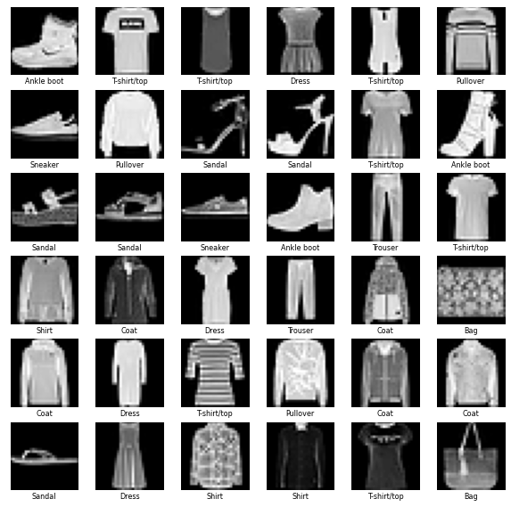

```python
# YOU ARE REQUIRED TO INSERT YOUR CODES IN THIS CELL
class_names = ["T-shirt/top", "Trouser", "Pullover", "Dress", "Coat", "Sandal", "Shirt", "Sneaker", "Bag", "Ankle boot"]
plot_x = X_train_full[0:36,].reshape(-1,28,28)
plot_y = y_train_full[:36,]

plt.figure(figsize=(10,10))

for i in range(6):
    for j in range(6):
        plt.subplot(6,6,i*6 + j + 1)
        plt.imshow(plot_x[i*6 + j], cmap='gray')
        plt.title(class_names[plot_y[i*6 + j]],fontsize=8, y = -0.2)
        plt.xticks([])
        plt.yticks([])
plt.show()
```

#### **Question 2.4**. Write code for the dense layer

[5 points]

We now develop a feed-forward neural networks with the architecture $784 \rightarrow 20(ReLU) \rightarrow 25(ReLU) \rightarrow 10(softmax)$. We first declare the code for the hidden layer with a linear operation and activation. Since we are implementing using TF 1.x syntax, we first import the compatible version of TF 1.x in TF 2.x.

```python
import tensorflow.compat.v1 as tf
tf.disable_v2_behavior()
```

```python
# YOU ARE REQUIRED TO INSERT YOUR CODES IN THIS CELL [3 marks]
import numpy as np

def dense_layer(x, num_neurons, name, activation=None):
    with tf.name_scope(name):
        num_inputs = int(x.get_shape()[1])
        stddev = 2 / np.sqrt(num_inputs)
        W_init = tf.random.normal([num_inputs, num_neurons], stddev= stddev, dtype= tf.float32)
        b_init= tf.random.normal([num_neurons], stddev= stddev, dtype= tf.float32)
        W= tf.Variable(W_init, name= "W")
        b= tf.Variable(b_init, name="b")
        z = tf.matmul(x, W) + b
    if activation == "sigmoid":
        return tf.sigmoid(z)#Insert your code here
    elif activation == "relu":
        return tf.nn.relu(z)#Insert your code here
    else:
        return z
dense_layer(tf.cast(plot_x, dtype = tf.float32), 20, "relu")
```

```
<tf.Tensor 'relu_1/add:0' shape=(36, 28, 20) dtype=float32>
```

#### **Question 2.5**. Declare your network and visualize quantities of interest using TensorBoard

[5 points]

- Gradients of trainable variables (weight matrices and biases) (Hint: use method `compute_gradients` with respect to the loss function).
- Hidden layers 1 and 2.

```python
num_hidden1 = 20
num_hidden2 = 25
num_outputs = 10
num_inputs = 784  #28 x 28
```

*Run the following cell to create necessary subfolders for this assignment. You must **not** modify these codes and **must** run it first*.

```python
# Create necessary subfolders to store immediate files for this assignment.

import os
if not os.path.exists("./models/dnn0"):
    os.makedirs("models/dnn0")
```

```python
inputs = tf.placeholder(tf.float32, shape=[None, num_inputs], name="inputs")
labels = tf.placeholder(tf.int32, shape=[None], name="labels")

with tf.name_scope("dnn"):
    hidden1 = dense_layer(inputs, 20, activation= 'relu', name= "layer1")#Insert your code here
    hidden2 = dense_layer(hidden1, 25, activation= 'relu', name= "layer2")#Insert your code here
    hidden3 = dense_layer(hidden2, 10, activation= None, name= "layer3")#Insert your code here
    logits = tf.nn.softmax(hidden3)#Insert your code here

with tf.name_scope("loss"):
    xentropy = tf.nn.sparse_softmax_cross_entropy_with_logits(labels=labels, logits=logits, name='xentropy')#Insert your code here
    loss = tf.reduce_mean(xentropy, name="loss")

with tf.name_scope("evaluation"):
    correct =  tf.nn.in_top_k(logits, labels, 1)#Insert your code here
    accuracy = tf.reduce_mean(tf.cast(correct, tf.float32))#Insert your code here

with tf.name_scope("train"):
    learning_rate = 0.001
    optimizer = tf.train.AdamOptimizer(learning_rate=learning_rate)#Insert your code here
    grads = optimizer.compute_gradients(loss)
    training_op = optimizer.apply_gradients(grads)

    for var in tf.trainable_variables():
        tf.summary.histogram(var.op.name + "/values", var)
    gradient = []
    for grad, var in grads:
        if grad is not None:
             gradient.append(tf.summary.histogram(var.op.name + "/gradients", grad))

# summary
accuracy_summary = tf.summary.histogram('accuracy', accuracy)#Insert your code here
```

```python
# YOU ARE REQUIRED TO INSERT YOUR CODES IN THIS CELL [5 marks]

# merge all summary
h1 = tf.summary.histogram('hidden1/activations', hidden1)
h2 = tf.summary.histogram('hidden2/activations', hidden2)
merged = tf.summary.merge([h1, h2] + gradient)#Insert your code here

init = tf.global_variables_initializer()
saver = tf.train.Saver()#Insert your code here

train_writer = tf.summary.FileWriter("models/dnn0/train", tf.get_default_graph())
test_writer = tf.summary.FileWriter("models/dnn0/test", tf.get_default_graph())

num_epochs = 50
batch_size = 128
```

#### **Question 2.6**. Train your network and report the resutls, and inspect the computational graph and visualize the gradients, hidden layers 1,2

[5 points]

The **first** part of this sub-question requires you to write codes in the following cell.

```python
# YOU ARE REQUIRED TO INSERT YOUR CODES IN THIS CELL

with tf.Session() as sess:
    init.run()
    print("Epoch\tTrain accuracy\tValid accuracy")
    for epoch in range(num_epochs):
        for idx_start in range(0, X_train.shape[0] - batch_size, batch_size):
            idx_end = [i for i in range(idx_start,idx_start+batch_size)]#Insert your code here
            X_batch, y_batch = X_train[idx_end,], y_train[idx_end,]#Insert your code here
            sess.run(training_op, feed_dict={inputs: X_batch, labels: y_batch})

        summary_train, acc_train = sess.run([merged,accuracy], feed_dict={inputs: X_train, labels: y_train})#Insert your code here
        summary_valid, acc_valid = sess.run([merged,accuracy], feed_dict={inputs: X_valid, labels: y_valid})#Insert your code here

        train_writer.add_summary(summary_train, epoch)
        test_writer.add_summary(summary_valid, epoch)

        print("{}\t{}\t{}".format(epoch, acc_train, acc_valid))

    save_path = saver.save(sess, "models/dnn0.ckpt")
```

```
Epoch	Train accuracy	Valid accuracy
0	0.729962944984436	0.7266666889190674
1	0.7475740909576416	0.7423333525657654
2	0.7595555782318115	0.7544999718666077
3	0.7640555500984192	0.7578333616256714
4	0.7662777900695801	0.7584999799728394
5	0.7754999995231628	0.7663333415985107
6	0.7751666903495789	0.7621666789054871
7	0.7778703570365906	0.765666663646698
8	0.7781851887702942	0.7613333463668823
9	0.7797777652740479	0.7671666741371155
10	0.7837777733802795	0.7706666588783264
11	0.7850740551948547	0.7698333263397217
12	0.7858518362045288	0.7698333263397217
13	0.7858889102935791	0.7689999938011169
14	0.7899629473686218	0.7716666460037231
15	0.7912777662277222	0.7730000019073486
16	0.7864259481430054	0.7699999809265137
17	0.7937407493591309	0.7735000252723694
18	0.7941296100616455	0.7726666927337646
19	0.7981851696968079	0.7741666436195374
20	0.797092616558075	0.7761666774749756
21	0.7992222309112549	0.7733333110809326
22	0.7942963242530823	0.7739999890327454
23	0.7933148145675659	0.7730000019073486
24	0.7959444522857666	0.7733333110809326
25	0.7994258999824524	0.7754999995231628
26	0.8000925779342651	0.7746666669845581
27	0.7919444441795349	0.7728333473205566
28	0.7979999780654907	0.7785000205039978
29	0.8029629588127136	0.778333306312561
30	0.7937963008880615	0.7699999809265137
31	0.8007592558860779	0.7795000076293945
32	0.801703691482544	0.7799999713897705
33	0.8024073839187622	0.7778333425521851
34	0.7957777976989746	0.7711666822433472
35	0.7997962832450867	0.7720000147819519
36	0.8040555715560913	0.7791666388511658
37	0.8020185232162476	0.7735000252723694
38	0.803685188293457	0.7758333086967468
39	0.8002407550811768	0.7739999890327454
40	0.8057592511177063	0.781333327293396
41	0.8061481714248657	0.777999997138977
42	0.8041296005249023	0.777999997138977
43	0.8068888783454895	0.7768333554267883
44	0.8052777647972107	0.7754999995231628
45	0.8038333058357239	0.7778333425521851
46	0.8036481738090515	0.7760000228881836
47	0.8027777671813965	0.7758333086967468
48	0.7875555753707886	0.76583331823349
49	0.8037962913513184	0.7788333296775818
INFO:tensorflow:models\dnn0.ckpt.data-00000-of-00001
INFO:tensorflow:600
INFO:tensorflow:models\dnn0.ckpt.index
INFO:tensorflow:600
INFO:tensorflow:models\dnn0.ckpt.meta
INFO:tensorflow:900
```

The **second** part of this subquestion requires you use the Tensorboard, find out relevant visualizations and input them into the markdown cell below. (*Hint*: A software to capture the screen such as *Snipping Tools* in *Windows* may help).

```python
from tensorboard import notebook
notebook.list()
notebook.start("--logdir ./models/dnn0")
```

[output not shown]

```
Reusing TensorBoard on port 6006 (pid 17960), started 1 day, 21:18:50 ago. (Use '!kill 17960' to kill it.)
```

[interactive chart not shown]

**YOU ARE REQUIRED TO INSERT YOUR OWN GRAPHICS IN THIS MARKDOWN CELL**

- **Hidden activations**:

[output not shown]

- **Parameter gradients**:

[output not shown]

## Part 3: Convolutional Neural Networks and Image Classification

**This part of the asssignment is designed to access your knowledge and coding skill with Tensorflow as well as hands-on experience with training Convolutional Neural Network (CNN).**

**The dataset we use for this part is a small animal dataset consisting of $2000$ images of cats, dogs, fishes and lions, each of which has 500 images.** You can download the dataset at [download here](https://drive.google.com/file/d/1t5b-pNMK5-uIK6wZIIHBluLY7tPK0JzV/view?usp=sharing) and then decompress to the folder the folder `datasets\Animals` for you in the assignment folder.**

**Your task is to build a CNN model using *TF 2.x* to classify these animals. You're provided with the module models.py, which you can find in the assignment folder, with some of the following classes:**

1. `AnimalsDatasetManager`: Support with loading and spliting the dataset into the train-val-test sets. It also help generate next batches for training. `AnimalsDatasetManager` will be passed to CNN model for training and testing.
2. `Layers`: A class providing some static method to create basic CNN layers.
3. `DefaultModel`: A base class for the CNN model.
4. `YourModel`: The class you'll need to implement to build the CNN model. It inherits some useful attributes and functions from the base class `DefaultModel`

Firstly, we need to run the following cells to load and preprocess the Animal dataset.

```python
%load_ext autoreload
%autoreload 2
```

```python
import os
# os.environ["CUDA_VISIBLE_DEVICES"]="-1"
import matplotlib.pyplot as plt
plt.style.use('ggplot')
%matplotlib inline
import models
from models import SimplePreprocessor, AnimalsDatasetManager, DefaultModel
```

```python
def create_label_folder_dict(adir):
    sub_folders= [folder for folder in os.listdir(adir)
                  if os.path.isdir(os.path.join(adir, folder))]
    label_folder_dict= dict()
    for folder in sub_folders:
#         item= {folder: os.path.abspath(os.path.join(adir, folder))}
        item= {folder: adir + '/' + folder}
        label_folder_dict.update(item)
    return label_folder_dict
```

```python
label_folder_dict= create_label_folder_dict("./datasets/Animals")
label_folder_dict
```

```
{'cats': './datasets/Animals/cats',
 'dogs': './datasets/Animals/dogs',
 'fishes': './datasets/Animals/fishes',
 'lions': './datasets/Animals/lions'}
```

The below code helps to create a data manager that contains all relevant methods used to manage and process our experimental data.

```python
sp = SimplePreprocessor(width=32, height=32)
data_manager = AnimalsDatasetManager([sp])
data_manager.load(label_folder_dict, verbose=100)
data_manager.process_data_label()
data_manager.train_valid_test_split()
```

```
cats 12500
Processed 100/500
Processed 200/500
Processed 300/500
Processed 400/500
Processed 500/500
dogs 12500
Processed 100/500
Processed 200/500
Processed 300/500
Processed 400/500
Processed 500/500
fishes 500
Processed 100/500
Processed 200/500
Processed 300/500
Processed 400/500
Processed 500/500
lions 500
Processed 100/500
Processed 200/500
Processed 300/500
Processed 400/500
Processed 500/500
```

Note that the object `data_manager` has the attributes relating to *the training, validation, and testing sets* as shown belows. You can use them in training your developped models in the sequel.

```python
print(data_manager.X_train.shape, data_manager.y_train.shape)
print(data_manager.X_valid.shape, data_manager.y_valid.shape)
print(data_manager.X_test.shape, data_manager.y_test.shape)
print(data_manager.classes)
```

```
(1600, 32, 32, 3) (1600,)
(200, 32, 32, 3) (200,)
(200, 32, 32, 3) (200,)
['cats' 'dogs' 'fishes' 'lions']
```

We now run the **default model** built in the **models.py** file which serves as a basic baseline to start the investigation. Follow the following steps to realize how to run a model and know the built-in methods associated to a model developped in the DefaultModel class.

We first initialize a default model from the DefaultModel class. Basically, we can define the relevant parameters of training a model including `num_classes`, `optimizer`, `learning_rate`, `batch_size`, and `num_epochs`.

```python
network1 = DefaultModel(name='network1',
                       num_classes=len(data_manager.classes),
                       optimizer='sgd',
                       batch_size= 64,
                       num_epochs = 20,
                       learning_rate=0.5)
```

The method `build_cnn()` assists us in building your convolutional neural network. You can view the code (in the **models.py** file) of the model behind a default model to realize how simple it is. Additionally, the method `summary()` shows the architecture of a model.

```python
network1.build_cnn()
network1.summary()
```

```
Model: "sequential_1"
_________________________________________________________________
 Layer (type)                Output Shape              Param #
=================================================================
 conv2d (Conv2D)             (None, 32, 32, 32)        896

 conv2d_1 (Conv2D)           (None, 32, 32, 32)        9248

 average_pooling2d (AverageP  (None, 16, 16, 32)       0
 ooling2D)

 conv2d_2 (Conv2D)           (None, 16, 16, 64)        18496

 conv2d_3 (Conv2D)           (None, 16, 16, 64)        36928

 average_pooling2d_1 (Averag  (None, 8, 8, 64)         0
 ePooling2D)

 flatten (Flatten)           (None, 4096)              0

 dense (Dense)               (None, 4)                 16388

=================================================================
Total params: 81,956
Trainable params: 81,956
Non-trainable params: 0
_________________________________________________________________
None
```

To train a model regarding to the datasets stored in `data_manager`, you can invoke the method `fit()` for which you can specify the batch size and number of epochs for your training.

```python
import os
os.environ['KMP_DUPLICATE_LIB_OK']='True'
network1.fit(data_manager, batch_size = 64, num_epochs = 20)
```

Here you can compute the accuracy of your trained model with respect to a separate testing set.

```python
network1.compute_accuracy(data_manager.X_test, data_manager.y_test)
```

```
0.25
```

Below shows how you can inspect the training progress.

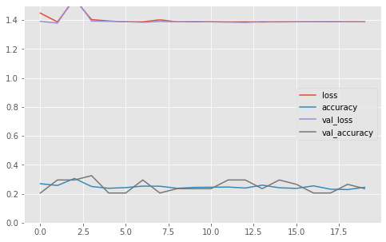

```python
network1.plot_progress()
```

You can use the method `predict()` to predict labels for data examples in a test set.

```python
network1.predict(data_manager.X_test[0:10])
```

```
array([0, 0, 0, 0, 0, 0, 0, 0, 0, 0], dtype=int64)
```

Finally, the method `plot_prediction()` visualizes the predictions for a test set in which several images are chosen to show the predictions.

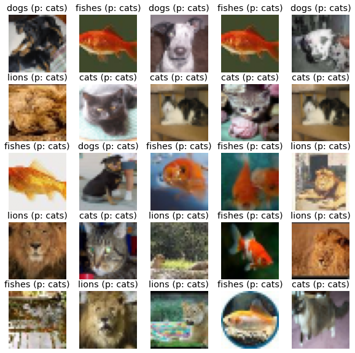

```python
network1.plot_prediction(data_manager.X_test, data_manager.y_test, data_manager.classes)
```

**Question 3.1** **After running the above cells to train the default model and observe the learning curve. Report your observation (i.e. did the model learn well? if not, what is the problem? what would you do to improve it?). Write your answer below.**

[5 points]

*#Your answer and observation here*

We could see that the model does not perform well because the loss and accuracy did not improve much from 1 epoch to the end. It predicts many picture wrong as the picture shows. The problem may be the learning rate is too large, the epoch is too small. Adam optimizer may be more suitable for the model. The network maybe too simple and can not learn very well. We could change some hyperparameters to imrove the model such as learning rate and batch_size, or increase the training epoch , or change the optimizer and the network. .....

**Question 3.2** **Normally the first parameter to tune in Deep Learning is learning rate. In this question, you'll try running the default model with different learning rates (recommended in the list $[0.0001, 0.001, 0.005, 0.01]$) by entering the value in the cell below and run it. You should write your own code below for this learning rate tuning. Note that you can set the attribute `verbose` of the `DefaultModel` class to `False` for keeping the training silently without showing its details. Report the learning rates you tried along with the validation accuracy for each learning rate. What is the final learning rate that you'll use? Why?.**

[5 points]

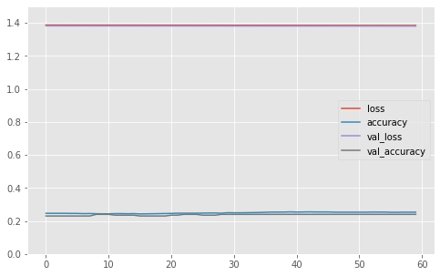

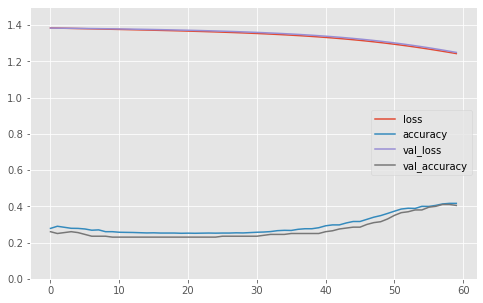

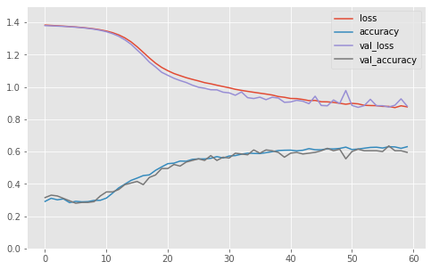

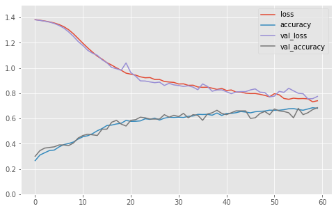

```python
#Write your code for tuning here
lrs = [0.0001,0.001,0.005,0.01]
for lr in lrs:
    network1 = DefaultModel(name='network1',
                           num_classes=len(data_manager.classes),
                           optimizer='sgd',
                           batch_size= 64,
                           num_epochs = 20,
                           learning_rate=lr,
                            verbose = False)
    network1.build_cnn()
    network1.fit(data_manager, batch_size = 64, num_epochs = 60)
    network1.plot_progress()
    network1.compute_accuracy(data_manager.X_test, data_manager.y_test)
    print("***************************************************")
```

*#Your answer and observation here*

We could see that when the learning rate is 0.0001, the model did not improve after several epochs because it will fall in the local mininum and can not jump out of local minimum. The larger the learning rate is, the faster the training speed is. But as the learning rate increases, the jitter degree of the training curve will also increase. Large learning rate could help reduce the training time, but can also make the model difficult to converge. I will choose the learning rate 0.005 as the initial learning rate, and decrease it to 0.001 after 50 epochs.

**For question 3.3 to 3.6, you'll need to write your own model in a way that makes it easy for you to experiment with different architectures as well as parameters. The goal is to be able to pass the parameters to initialize a new instance of `YourModel` to build different network architectures with different parameters. Below are descriptions of some parameters for `YourModel`, which you can find in function `__init__()` for the class `DefaultModel`:**

1. `num_blocks`: an integer specifying the number of blocks in our network. Each block has the pattern `[conv, batch norm, activation, conv, batch norm, activation, mean pool, dropout]`. All convolutional layers have filter size $(3, 3)$, strides $(1, 1)$ and 'SAME' padding, and all mean pool layers have strides $(2, 2)$ and 'SAME' padding. The network will consists of a few blocks before applying a linear layer to output the logits for the softmax layer.
2. `feature_maps`: the number of feature maps in the first block of the network. The number of feature_maps will double in each of the following block. To make it convenient for you, we already calculated the number of feature maps for each block for you in line $106$
3. `drop_rate`: the keep probability for dropout. Setting `drop_rate` to $0.0$ means not using dropout.
4. `batch_norm`: the batch normalization function is used or not. Setting `batch_norm` to `None` means not using batch normalization.

```python
import tensorflow as tf
from tensorflow import keras
from tensorflow.keras import layers, models
from keras import Sequential

from keras.layers import *
from keras.utils.np_utils import to_categorical
```

**Question 3.3** **Write the code of the `YourModel` class here. Note that this class will inherit from the `DefaultModel` class. You'll only need to re-write the code for the `build_cnn` method for the `YourModel` class from the cell below which is inherited from the `DefaultModel` class.**

[5 points]

```python
class YourModel(DefaultModel):
    def __init__(self,
                 name='network1',
                 width=32, height=32, depth=3,
                 num_blocks=2,
                 feature_maps=32,
                 num_classes=4,
                 drop_rate=0.2,
                 batch_norm = None,
                 is_augmentation = False,
                 activation_func='relu',
                 optimizer='adam',
                 batch_size=10,
                 num_epochs= 20,
                 learning_rate=0.0001,
                 verbose= True):
        super(YourModel, self).__init__(name, width, height, depth, num_blocks, feature_maps, num_classes, drop_rate, batch_norm, is_augmentation,
                                        activation_func, optimizer, batch_size, num_epochs, learning_rate, verbose)

    def build_cnn(self,X,Y):
        #Insert your code here
        self.model=Sequential()
        self.model.add(Conv2D(self.feature_maps[0],(3,3),strides=(1,1),input_shape=X.shape[1:],padding='same',activation=None,kernel_initializer='uniform'))
        if self.batch_norm: self.model.add(BatchNormalization())
        self.model.add(Activation(self.activation_func))
        self.model.add(Conv2D(self.feature_maps[0],(3,3),strides=(1,1),padding='same',activation=None,kernel_initializer='uniform'))
        if self.batch_norm: self.model.add(BatchNormalization())
        self.model.add(Activation(self.activation_func))
        self.model.add(AveragePooling2D((2,2), padding='same'))
        self.model.add(Dropout(self.drop_rate))

        for _ in range(self.num_blocks-1):
            self.model.add(Conv2D(self.feature_maps[_+1],(3,3),strides=(1,1),padding='same',activation=None,kernel_initializer='uniform'))
            if self.batch_norm: self.model.add(BatchNormalization())
            self.model.add(Activation(self.activation_func))
            self.model.add(Conv2D(self.feature_maps[_+1],(3,3),strides=(1,1),padding='same',activation=None,kernel_initializer='uniform'))
            if self.batch_norm: self.model.add(BatchNormalization())
            self.model.add(Activation(self.activation_func))
            self.model.add(AveragePooling2D((2,2), padding='same'))
            self.model.add(Dropout(self.drop_rate))


        self.model.add(Flatten())  #拉平
        self.model.add(Dense(self.num_classes,activation='softmax'))

        self.model.compile(optimizer=self.optimizer, loss='sparse_categorical_crossentropy', metrics=['accuracy'])

drop_out_network = YourModel(name='network1',
             feature_maps=32,
             num_classes=len(data_manager.classes),
             num_blocks=4,
             drop_rate= 0.25, # enter your final dropout rate value here
             batch_norm=None,
             optimizer='adam',
             learning_rate= 1e-3)
drop_out_network.build_cnn(data_manager.X_train, data_manager.y_train)
drop_out_network.summary()
# drop_out_network.fit(data_manager, batch_size = 64, num_epochs = 100)
```

```
Model: "sequential_104"
_________________________________________________________________
 Layer (type)                Output Shape              Param #
=================================================================
 conv2d_410 (Conv2D)         (None, 32, 32, 32)        896

 activation_354 (Activation)  (None, 32, 32, 32)       0

 conv2d_411 (Conv2D)         (None, 32, 32, 32)        9248

 activation_355 (Activation)  (None, 32, 32, 32)       0

 average_pooling2d_179 (Aver  (None, 16, 16, 32)       0
 agePooling2D)

 dropout_185 (Dropout)       (None, 16, 16, 32)        0

 conv2d_412 (Conv2D)         (None, 16, 16, 64)        18496

 activation_356 (Activation)  (None, 16, 16, 64)       0

 conv2d_413 (Conv2D)         (None, 16, 16, 64)        36928

 activation_357 (Activation)  (None, 16, 16, 64)       0

 average_pooling2d_180 (Aver  (None, 8, 8, 64)         0
 agePooling2D)

 dropout_186 (Dropout)       (None, 8, 8, 64)          0

 conv2d_414 (Conv2D)         (None, 8, 8, 128)         73856

 activation_358 (Activation)  (None, 8, 8, 128)        0

 conv2d_415 (Conv2D)         (None, 8, 8, 128)         147584

 activation_359 (Activation)  (None, 8, 8, 128)        0

 average_pooling2d_181 (Aver  (None, 4, 4, 128)        0
 agePooling2D)
```

[output cut: 11 more lines]

```
 average_pooling2d_182 (Aver  (None, 2, 2, 256)        0
 agePooling2D)

 dropout_188 (Dropout)       (None, 2, 2, 256)         0

 flatten_52 (Flatten)        (None, 1024)              0

 dense_60 (Dense)            (None, 4)                 4100

=================================================================
Total params: 1,176,356
Trainable params: 1,176,356
Non-trainable params: 0
_________________________________________________________________
None
```

**Question 3.4** **Once writing your own models, you should be able to use it to experiment with dropout or batch normalization. In this question, you'll use your model to finetune the dropout rate. Report the `drop_rate` rates you tried along with the validation accuracy for each rate (recomended range: 0.2 to 0.5). What is the final `drop_rate` rate that you'll use? Did dropout improve performance? Did it help reduce overfitting? Note that in this experiment, you should set `batch_norm` to `None`, meaning that we do not use the batch normalization.**

[5 points]

# *Write your answer and observation here*

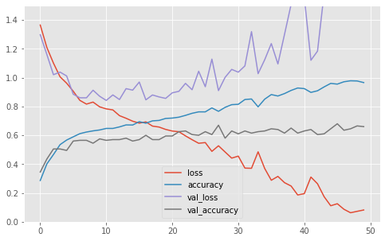

```
dp: 0
```

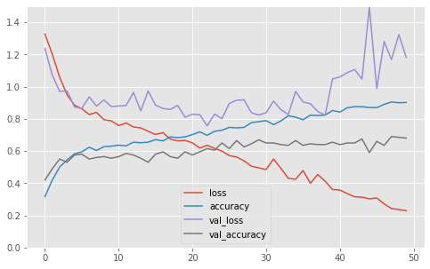

```
dp: 0.1
```

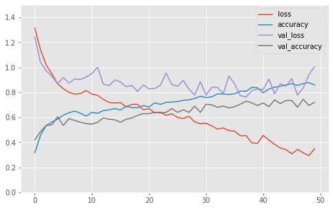

```
dp: 0.2
```

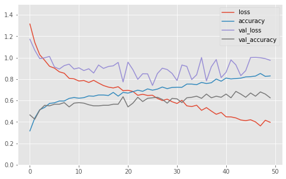

```
dp: 0.3
```

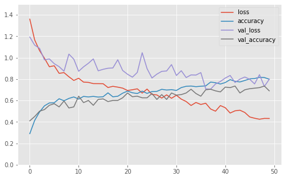

```
dp: 0.4
```

```python
dps = [0, 0.1, 0.2, 0.3, 0.4]
for dp in dps:
    drop_out_network = YourModel(name='network1',
                            feature_maps=32,
                            num_classes=len(data_manager.classes),
                            num_blocks=4,
                            drop_rate= dp, # enter your final dropout rate value here
                            batch_norm=None,
                            optimizer='adam',
                            learning_rate= 5e-4,
                            verbose = False)
    drop_out_network.build_cnn(data_manager.X_train, data_manager.y_train)
    drop_out_network.fit(data_manager, batch_size = 64, num_epochs = 50)
    drop_out_network.plot_progress()
    print("dp:", dp)
    drop_out_network.compute_accuracy(data_manager.X_train, data_manager.y_train)
    drop_out_network.compute_accuracy(data_manager.X_valid, data_manager.y_valid)
    print("***************************************************")
```

**Question 3.5** **Now, let's try using batch normalization. What is the validation and test result? Does it improve the model? How does it compare to the model using dropout? To have a fair comparison, in this experiment, we set `drop_rate=0` to not use the dropout.**

[5 points]

# *Write your answer and observation here*

```python
batch_norm_network = YourModel(name='network2',
                     feature_maps=32,
                     num_classes=len(data_manager.classes),
                     num_blocks=4,
                     drop_rate= 0,
                     batch_norm=True, #do batch norm
                     optimizer='adam',
                     learning_rate= 5e-4,
                    verbose = True)

batch_norm_network.build_cnn(data_manager.X_train, data_manager.y_train)
batch_norm_network.fit(data_manager, batch_size = 64, num_epochs = 50)

no_batch_norm_network = YourModel(name='network2',
                     feature_maps=32,
                     num_classes=len(data_manager.classes),
                     num_blocks=4,
                     drop_rate= 0,
                     batch_norm=False, #do batch norm
                     optimizer='adam',
                     learning_rate= 5e-4,
                    verbose = True)

no_batch_norm_network.build_cnn(data_manager.X_train, data_manager.y_train)
no_batch_norm_network.fit(data_manager, batch_size = 64, num_epochs = 50)
```

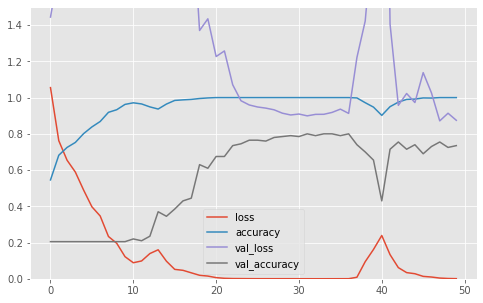

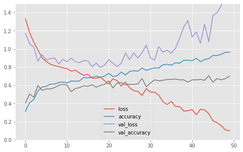

```
0.699999988079071
```

```python
batch_norm_network.plot_progress()
batch_norm_network.compute_accuracy(data_manager.X_train, data_manager.y_train)
batch_norm_network.compute_accuracy(data_manager.X_valid, data_manager.y_valid)
no_batch_norm_network.plot_progress()
no_batch_norm_network.compute_accuracy(data_manager.X_train, data_manager.y_train)
no_batch_norm_network.compute_accuracy(data_manager.X_valid, data_manager.y_valid)
```

**Question 3.6** **Finally, you should try to train the best model by trying different configurations for `num_blocks`, `feature_maps`, `optimizer`, `learning_rate`, `batch_size`, `keep_prob` and `batch_norm`. Briefly report the experiments that you try and your observation in the answer below. Also, run the cells below with the best configuration you found.**

[5 points]

```python
best_network = YourModel(name='network3',
                     feature_maps=64,
                     num_classes=len(data_manager.classes),
                     num_blocks=5,
                     drop_rate= 0.75,
                     batch_norm=True, #do batch norm
                     optimizer='nadam',
                     learning_rate= 8e-4,
                     verbose = True)

best_network.build_cnn(data_manager.X_train, data_manager.y_train)
best_network.fit(data_manager, batch_size = 32, num_epochs = 100)
```

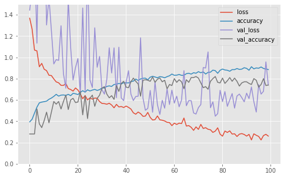

```
0.7400000095367432
```

```python
best_network.plot_progress()
best_network.compute_accuracy(data_manager.X_train, data_manager.y_train)
best_network.compute_accuracy(data_manager.X_valid, data_manager.y_valid)
```

# *Write your answer and discussion here*

I try feature_maps of 8,16,32,64, and drop_rate from 0.2 to 0.8, and learning rate from 1e-4 to 2e-3. I found that when the feature_maps is large and drop_rate is small, the model is easy to overfit. If the feature_maps is small, the model is too simple to fit the data set. So, I set large feature_maps, large drop rate and 8e-4 learning rate and found the model performs well.

**Question 3.7** **We now try to apply data augmentation to improve the performance. Extend the code of the class `YourModel` so that if the attribute `is_augmentation` is set to `True`, we apply the data augmentation.**

[5 points]

```python
from keras.preprocessing.image import ImageDataGenerator
```

Wtire your code in the cell below. Hint that you can rewrite the code of `fit` method to apply the data augmentation. In addition, you can copy the code of `build_cnn` method above to reuse here.

```python
class YourModel(DefaultModel):
    def __init__(self,
                 name='network1',
                 width=32, height=32, depth=3,
                 num_blocks=2,
                 feature_maps=32,
                 num_classes=4,
                 drop_rate=0.2,
                 batch_norm = None,
                 is_augmentation = False,
                 activation_func='relu',
                 optimizer='adam',
                 batch_size=10,
                 num_epochs= 20,
                 learning_rate=0.0001):
        super(YourModel, self).__init__(name, width, height, depth, num_blocks, feature_maps, num_classes, drop_rate, batch_norm, is_augmentation,
                                        activation_func, optimizer, batch_size, num_epochs, learning_rate)

    def build_cnn(self,X,Y):
        #reuse code of previous section here
        self.model=Sequential()
        self.model.add(Conv2D(self.feature_maps[0],(3,3),strides=(1,1),input_shape=X.shape[1:],padding='same',activation=None,kernel_initializer='uniform'))
        if self.batch_norm: self.model.add(BatchNormalization())
        self.model.add(Activation(self.activation_func))
        self.model.add(Conv2D(self.feature_maps[0],(3,3),strides=(1,1),padding='same',activation=None,kernel_initializer='uniform'))
        if self.batch_norm: self.model.add(BatchNormalization())
        self.model.add(Activation(self.activation_func))
        self.model.add(AveragePooling2D((2,2), padding='same'))
        self.model.add(Dropout(self.drop_rate))

        for _ in range(self.num_blocks-1):
            self.model.add(Conv2D(self.feature_maps[_+1],(3,3),strides=(1,1),padding='same',activation=None,kernel_initializer='uniform'))
            if self.batch_norm: self.model.add(BatchNormalization())
            self.model.add(Activation(self.activation_func))
            self.model.add(Conv2D(self.feature_maps[_+1],(3,3),strides=(1,1),padding='same',activation=None,kernel_initializer='uniform'))
            if self.batch_norm: self.model.add(BatchNormalization())
            self.model.add(Activation(self.activation_func))
            self.model.add(AveragePooling2D((2,2), padding='same'))
            self.model.add(Dropout(self.drop_rate))


        self.model.add(Flatten())  #拉平
        self.model.add(Dense(self.num_classes,activation='softmax'))

        self.model.compile(optimizer=self.optimizer, loss='sparse_categorical_crossentropy', metrics=['accuracy'])

    def fit(self, data_manager, batch_size=None, num_epochs=None):
        #insert your code here
        batch_size = self.batch_size if batch_size is None else batch_size
        num_epochs = self.num_epochs if num_epochs is None else num_epochs
        image_gen_train = ImageDataGenerator(
                            rotation_range=45,
                            width_shift_range=.15,
                            height_shift_range=.15,
                            horizontal_flip=False,
                            zoom_range=0.5)
        image_gen_train.fit(data_manager.X_train, augment=True, rounds=2)
        self.model.compile(optimizer=self.optimizer, loss='sparse_categorical_crossentropy', metrics=['accuracy'])
        self.history = self.model.fit(image_gen_train.flow(data_manager.X_train, data_manager.y_train),
                                      validation_data = (data_manager.X_valid, data_manager.y_valid),
                                      epochs = num_epochs, batch_size = batch_size, verbose= self.verbose)
```

**Question 3.7** **Leverage the data augmentation with the best model you found before and try to observe if you can really boost the performance.**

[5 points]

# *Write your answer and observation here*

The data augmentation can help slove the problems of overfitting and boosts the model performance.

```python
augmentation_network = YourModel(name='network5',
                     feature_maps=64,
                     num_classes=len(data_manager.classes),
                     num_blocks=5,
                     drop_rate= 0.5, # enter your final keep_prob value here
                     batch_norm=True,
                     is_augmentation= True,
                     optimizer='nadam',
                     learning_rate= 8e-4)

augmentation_network.build_cnn(data_manager.X_train, data_manager.y_train)
augmentation_network.summary()
```

```
Model: "sequential_124"
_________________________________________________________________
 Layer (type)                Output Shape              Param #
=================================================================
 conv2d_500 (Conv2D)         (None, 32, 32, 64)        1792

 batch_normalization_420 (Ba  (None, 32, 32, 64)       256
 tchNormalization)

 activation_444 (Activation)  (None, 32, 32, 64)       0

 conv2d_501 (Conv2D)         (None, 32, 32, 64)        36928

 batch_normalization_421 (Ba  (None, 32, 32, 64)       256
 tchNormalization)

 activation_445 (Activation)  (None, 32, 32, 64)       0

 average_pooling2d_224 (Aver  (None, 16, 16, 64)       0
 agePooling2D)

 dropout_230 (Dropout)       (None, 16, 16, 64)        0

 conv2d_502 (Conv2D)         (None, 16, 16, 128)       73856

 batch_normalization_422 (Ba  (None, 16, 16, 128)      512
 tchNormalization)

 activation_446 (Activation)  (None, 16, 16, 128)      0

 conv2d_503 (Conv2D)         (None, 16, 16, 128)       147584

 batch_normalization_423 (Ba  (None, 16, 16, 128)      512
 tchNormalization)

 activation_447 (Activation)  (None, 16, 16, 128)      0

 average_pooling2d_225 (Aver  (None, 8, 8, 128)        0
 agePooling2D)

```

[output cut: 54 more lines]

```
 average_pooling2d_228 (Aver  (None, 1, 1, 1024)       0
 agePooling2D)

 dropout_234 (Dropout)       (None, 1, 1, 1024)        0

 flatten_62 (Flatten)        (None, 1024)              0

 dense_70 (Dense)            (None, 4)                 4100

=================================================================
Total params: 18,863,172
Trainable params: 18,855,236
Non-trainable params: 7,936
_________________________________________________________________
None
```

```python
augmentation_network.fit(data_manager, batch_size = 32, num_epochs = 100)
```

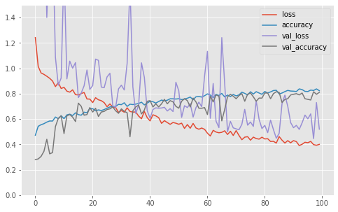

```
0.8100000023841858
```

```python
augmentation_network.plot_progress()
augmentation_network.compute_accuracy(data_manager.X_train, data_manager.y_train)
augmentation_network.compute_accuracy(data_manager.X_valid, data_manager.y_valid)
```

END OF ASSIGNMENT